# ANOVA and Intro to Linear Regression

## Lab Report Template

Your reproducible lab report: Before you get started, please download the R Markdown template for this lab. Remember all of your code and answers go in this document:

```r
download.file("https://jacobfhsmith.github.io/STA101-Fall-2021/sta101_lab8.Rmd", destfile="sta101_lab8.Rmd")
```

## Packages

We will be using `tidyverse` again today.

```r
library(tidyverse)
```

## Data

Here, you will be working with demographic data from counties in the Midwest from the `midwest` data set in R. This data set is already loaded into R. You can learn more about this dataset and the variables it contains by typing ?midwest into the console.

## ANOVA

Analysis of variance (ANOVA) answers questions that fall into the below hypothesis testing framework:

$H_0:$ Numeric variable X is the same across all subgroups

$H_A:$ At least one of the subgroups has a different X than the others

A variable in the `midwest`data set called `category` which divides the counties into 16 groups..Using ANOVA, we could test whether population density is different based upon the category.

```r
aov1 <- aov(midwest$popdensity ~ midwest$category)
summary(aov1)
```

```
##                   Df    Sum Sq   Mean Sq F value Pr(>F)
## midwest$category  15 7.222e+09 481496727   11.02 <2e-16 ***
## Residuals        421 1.839e+10  43686129
## ---
## Signif. codes:  0 '***' 0.001 '**' 0.01 '*' 0.05 '.' 0.1 ' ' 1
```

Here we can see that we have a large F value and low p-value (well below 0.05), allowing us to reject our null hypothesis that population density is the same across all categories in favor of the alternative that at least one category has a different population density than the others.

## Exercise 1 (20 points)

Is there significant difference in the percentage of people with a college degree (`percollege`) depending on the state the county is located in (`state`)? Write out your null and alternative hypotheses and then use `aov()` to test it.

## Simple Linear Regression

The rest of the lab will focus on simple linear regression.

This is the equation of the population regression line:

$$Y_i = \beta_0 + \beta_1 X_i + \epsilon_i, \text{ where } \epsilon_i \overset{iid}{\sim} N(0, \sigma^2) \text{ for all } i$$
(Typically, however, we will be working with a sample.)

Linear Regression has 4 Conditions:

- Linearity: The relationship between X and the mean of Y is linear and residuals have zero mean.
- Homoscedasticity: The variance of residual is the same for any value of X.
- Independence: Observations are independent of each other. (This is particularly a concern when working with time series data.)
- Normality: For any fixed value of X, Y is normally distributed.

### Visualization

Let’s say that we are interested in the relationship between the percentage of people with a college degree and the percentage below poverty. We can plot this using `ggplot2`.

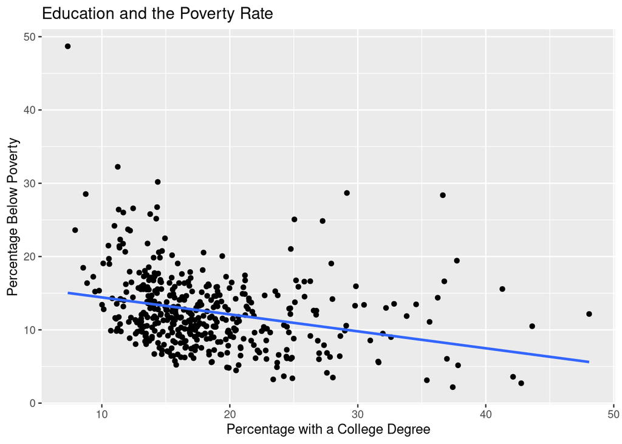

```r
midwest %>%
  ggplot(aes(x = percollege, y = percbelowpoverty)) +
  geom_point() +
  geom_smooth(method='lm', se=FALSE) +
  labs(x = "Percentage with a College Degree", y = "Percentage Below Poverty") +
  ggtitle("Education and the Poverty Rate")
```

## Exercise 2 (10 points)

Please describe what you see in the above plot. Does it look like there is a linear relationship between the variables? Please provide evidence.

## Exercise 3 (15 points)

Now it’s your turn! Please make a plot using `ggplot2` showing the relationship between the percentage of people with a *high school diploma* (`perchsd`) or the equivalent and the poverty rate. What do you observe here? How does it compare to the previous plot. Please provide evidence.

## lm()

The `lm()` command can be used to run a linear regression. This function has two required arguments: the data and the formula of the regression line. Y~ X1 is the formula for a simple linear regression, with Y being the response and X1 being the predictor. (Later, we will add addition variables by adding + X2 + X3… to the formula.)

Let’s fit a simple linear regression model for our first scatter plot where we use the poverty rate as the response (dependent) variable and percentage with a college degree as the explanatory (independent) variable.

```r
model1 <- lm(data = midwest, percbelowpoverty ~ percollege)
summary(model1)
```

```
##
## Call:
## lm(formula = percbelowpoverty ~ percollege, data = midwest)
##
## Residuals:
##    Min     1Q Median     3Q    Max
## -8.088 -3.489 -0.748  2.514 33.649
##
## Coefficients:
##             Estimate Std. Error t value Pr(>|t|)
## (Intercept) 16.73964    0.73083  22.905  < 2e-16 ***
## percollege  -0.23144    0.03784  -6.116 2.13e-09 ***
## ---
## Signif. codes:  0 '***' 0.001 '**' 0.01 '*' 0.05 '.' 0.1 ' ' 1
##
## Residual standard error: 4.948 on 435 degrees of freedom
## Multiple R-squared:  0.07919,    Adjusted R-squared:  0.07707
## F-statistic: 37.41 on 1 and 435 DF,  p-value: 2.134e-09
```

How would we interpret this output?

- An intercept of 16.74 means that, on average, if nobody in a county had a college degree, we would expect 16.74 percent of the population to be living in poverty.
  - The p-value here is below 0.05; for an intercept, this means that we can discern that the regression line does not cross the y-axis at 0.
- A one percentage point increase in the percentage of people with a college degree, on average, translates to a 0.23 percentage point *decrease* in the percentage of people living below poverty in a Midwest county.
  - The p-value below 0.05 tells us that this is a statistically significant predictor.
- The $R^2$ value of 0.079 means that the percentage of people with a college degree explains about 8 percent of the variability in poverty rate.

## Exercise 4 (25 points)

Use `lm()` to fit a simple linear regression model for the variables you used for the scatter plot in Exercise 3 (percentage with a high school degree and the poverty rate). Then, please interpret the output. You should discuss the intercept, slope, and $R^2$ value.

### Conditions

As we discussed earlier in the lab, there are 4 conditions for linear regression. We already considered linearity, but what about the equal variance assumption? Using `augment` we can collect residuals and then plot the predicted poverty rate against the value of the residuals. We want the points to form a band around horizontal 0 line and not form a pattern (for example, a fan shape would be concerning.)

Here is some code to do this for the college degree regression we ran earlier.

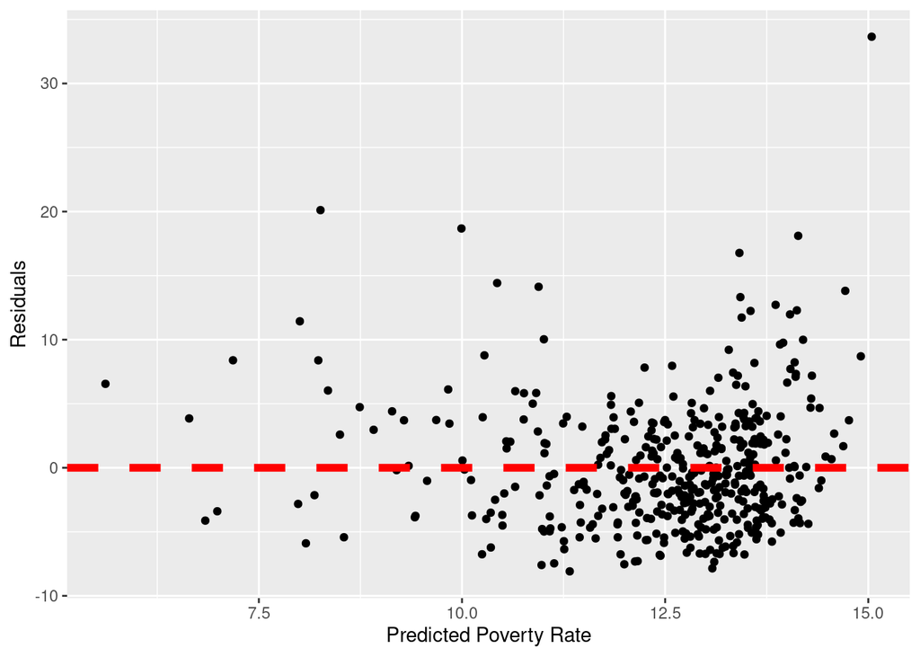

```r
modelaug <- augment(model1)

ggplot(modelaug, mapping = aes(x = .fitted, y = .resid)) +
  geom_point() +
  geom_hline(yintercept = 0, lwd = 2, col = "red", lty = 2) +
  labs(x = "Predicted Poverty Rate", y = "Residuals")
```

One thing that might be a bit concerning here is that there seems to be a slight upward curve when the predicted poverty rate is above about 13.

Finally, let’s consider normality (independence isn’t as much of a concern here since we are not working with time series data).

We can plot a histogram and a qq-plot to assess normality.

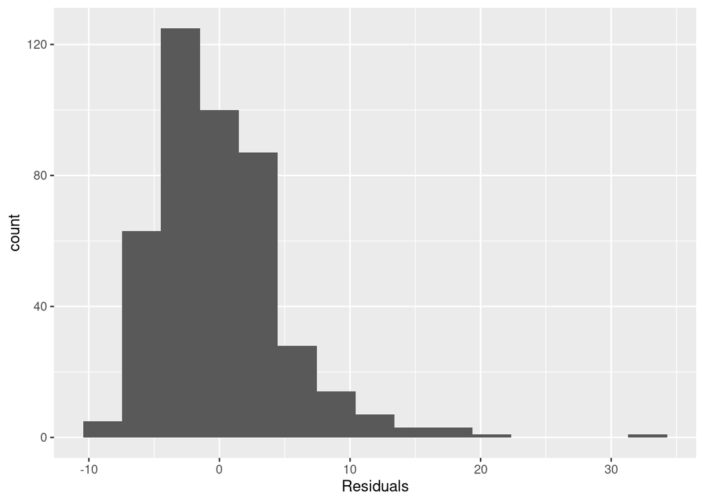

```r
ggplot(modelaug, mapping = aes(x = .resid)) +
  geom_histogram(bins = 15) +
  labs(x = "Residuals")
```

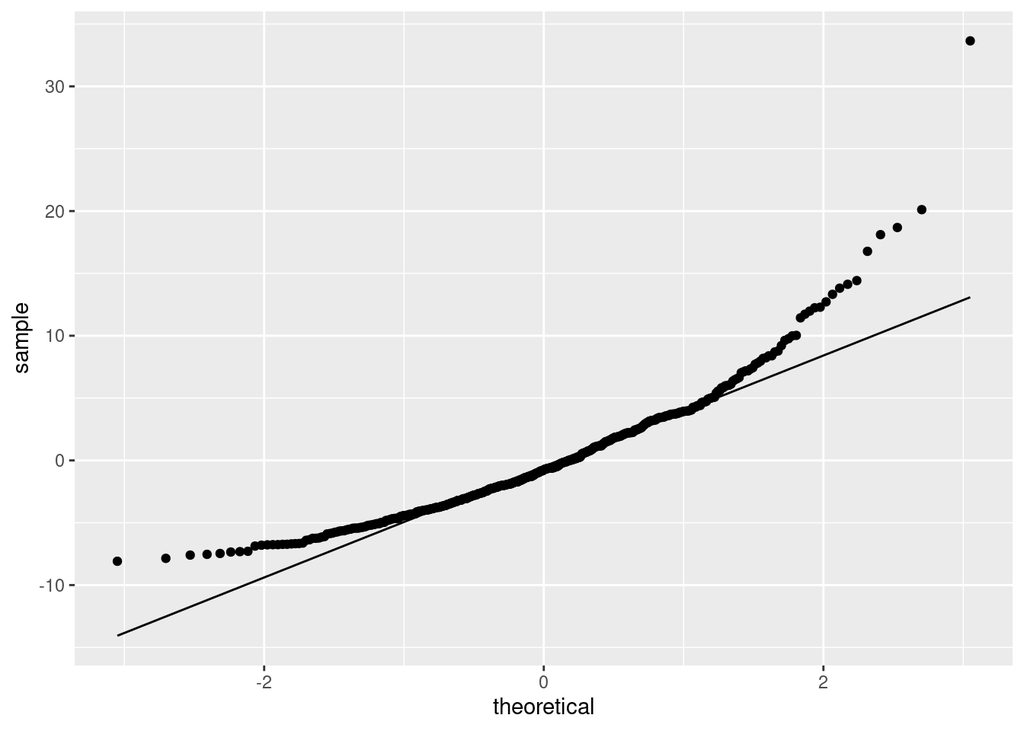

```r
ggplot(modelaug, mapping = aes(sample = .resid)) +
  stat_qq() +
  stat_qq_line()
```

The histogram shows a right skew and the q-q plot shows that a number of points do not fall along the q-q line. Thus, we have some evidence to suggest that there may be a violation of the normality condition.

## Exercise 5 (20 points)

For the regression you made for part 4, please use `augment` to collect the residuals and then make a scatter plot to assess the equal variance assumption.

Then, please make a histogram and q-q plot to assess the normality assumption. Please discuss what you observe.

### Multiple Regression

Next week, we will turn to multiple regression. For this last exercise, I would like you to practice running one.

## Exercise 6 (10 points)

Please run a linear model with a continuous response variable and two continuous independent variables (you can also use a dummy variable as a predictor, but not as the response variable). (Next week, we will discuss interpretation of multiple regression models. For now, please just practice running it.)

A lab made by Di Deng for Summer 2020 and modified by Irene Ji for Spring 2021 was used as a guide.